# Titanic

## Introduction

In this exercise we tried to explore the titanic dataset. First we need to load the data using pandas then process the data to data frame. Later we need to data cleaning and data analysis using pandas and create visualization using matplotlib.

1. Import the Required Libraries

```python
import pandas as pd
import matplotlib.pyplot as plt
import numpy as np
```

This for import to open csv file using pandas and matplotlib for creating static, animated, and interactive visualizations in Python.

2. Load the Dataset

Load the Titanic dataset from a CSV file named 'titanic.csv' into a Pandas DataFrame.

```python
df = pd.read_csv('titanic.csv')
```

This process to convert the data to data frame.

3. Data Exploration

In this step we want to know the data structure.

```python
df.head(5)
```

|  | PassengerId | Survived | Pclass | Name | Sex | Age | SibSp | Parch | Ticket | Fare | Cabin | Embarked |
| --- | --- | --- | --- | --- | --- | --- | --- | --- | --- | --- | --- | --- |
| 0 | 1 | 0 | 3 | Braund, Mr. Owen Harris | male | 22.0 | 1 | 0 | A/5 21171 | 7.2500 | NaN | S |
| 1 | 2 | 1 | 1 | Cumings, Mrs. John Bradley (Florence Briggs Th... | female | 38.0 | 1 | 0 | PC 17599 | 71.2833 | C85 | C |
| 2 | 3 | 1 | 3 | Heikkinen, Miss. Laina | female | 26.0 | 0 | 0 | STON/O2. 3101282 | 7.9250 | NaN | S |
| 3 | 4 | 1 | 1 | Futrelle, Mrs. Jacques Heath (Lily May Peel) | female | 35.0 | 1 | 0 | 113803 | 53.1000 | C123 | S |
| 4 | 5 | 0 | 3 | Allen, Mr. William Henry | male | 35.0 | 0 | 0 | 373450 | 8.0500 | NaN | S |

To print the first 5 rows of the data frame to understand the structure.

```python
df.shape
```

```
(891, 12)
```

Print information about the how many columns and rows.

```python
df.info
```

[output not shown]

[output cut: 25 more lines]

```python
df.describe
```

[output not shown]

[output cut: 25 more lines]

4. Data Cleaning

```python
df.isnull().sum()
```

```
PassengerId      0
Survived         0
Pclass           0
Name             0
Sex              0
Age            177
SibSp            0
Parch            0
Ticket           0
Fare             0
Cabin          687
Embarked         2
dtype: int64
```

Identify missing values in the dataset

```python
df1 = df.copy()
df1["Age"] = df1["Age"].mean()
df1.isnull().sum()
```

```
PassengerId      0
Survived         0
Pclass           0
Name             0
Sex              0
Age              0
SibSp            0
Parch            0
Ticket           0
Fare             0
Cabin          687
Embarked         2
dtype: int64
```

df1 used to keep the original dataframe from any changes.

```python
df1 = df1.dropna()
```

To drop missing value in cabin and embarked column.

5. Data Analysis

To see the analyse the data from the dataframe.

```python
df1['Sex'].value_counts()
```

```
Sex
male      107
female     95
Name: count, dtype: int64
```

This step used to count the the amount of the gender (male / female) in the data set.

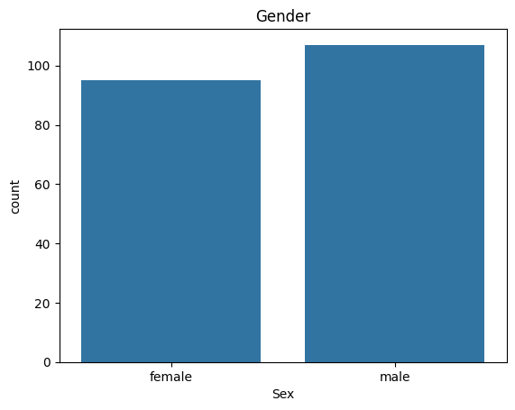

```python
import seaborn as sns
sns.countplot(x='Sex', data=df1,)
plt.title('Gender')
plt.show()
```

Calculate and display the count of passengers by gender and visualize the data in bar graph.

```python
df1['Age'].mean()
```

```
29.699117647058813
```

Compute the average age of passengers.

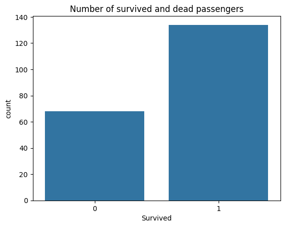

```python
sns.countplot(x='Survived', data=df1,)
label=["Dead", "Survived"]
plt.title('Number of survived and dead passengers')
plt.show()
```

To see amount of people survived.

6. Correlation between survival and ticket class

To see their economic class boarded to the Titanic.

Process on calculating the amount people boarded according to the ticket class and the ratio.

```python
survival_rate_by_class = df1.groupby('Pclass')['Survived'].mean() * 100

print(survival_rate_by_class)
```

```
Pclass
1    66.091954
2    81.250000
3    50.000000
Name: Survived, dtype: float64
```

To see the survival rates based on the ticket class.

6. Data Visualization

Create a bar chart to visualize the survival rate by passenger class.

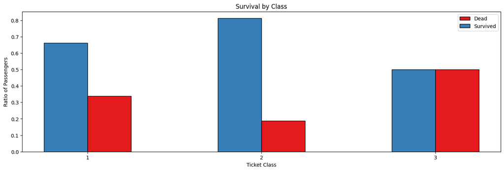

```python
fig, axes = plt.subplots(nrows = 1, ncols = 1, figsize=(17, 5))

width=0.25
ind = np.arange(3)
bar1 = axes.bar(ind, survived, width,color='#377eb8', edgecolor = "Black")
bar2 = axes.bar(ind+width, dead, width,color='#e41a1c', edgecolor = "Black")
axes.legend((bar2, bar1), ('Dead', 'Survived'))
axes.set_title("Survival by Class")
axes.set_xlabel("Ticket Class")
axes.set_ylabel("Ratio of Passengers")
axes.set_xticks(ind+width/2)
axes.set_xticklabels(["1", "2", "3"])
plt.show()
```

Add appropriate labels and a title to the chart.